# haifeng bsd treatment

This document details the analysis of proteomics data acquired to look at bsd treated ewing sarcoma cells.

## Setting up the environment

These are packages you will need for this notebook. For exact versions used, please refer to the session info at the bottom of this notebook.

```r
##########################################################################################
library('tidyverse')
library('DEqMS')
library('RColorBrewer')
library('ggrepel')
```

I want to set a base directory that we can use as a link to the directory where we will do most of the work. I use two directories here because the Workspace is what is pushed to GitHub and contains scripts and plot files, but the Repository is where more of the big data is stored that does not get pushed.

```r
##########################################################################################
generalDatasets = 'C:/Users/chughes/Documents/bccrc/projectsRepository/generalDatasets'
baseWorkspace = 'C:/Users/chughes/Documents/bccrc/projectsWorkspace/sorensenLab/relatedToOthers'
baseRepository = 'D:/msDataTemp/proteomics20220326_haifengBsdPtxTc32Set'
#generalDatasets = 'C:/Users/chris/OneDrive/Documents/bccrc/projectsRepository/generalDatasets'
#baseWorkspace = 'C:/Users/chris/OneDrive/Documents/bccrc/projectsWorkspace/sorensenLab/relatedToYbx1'
#baseRepository = 'C:/Users/chris/OneDrive/Documents/bccrc/projectsRepository/sorensenLab/relatedToYbx1'
```

## Data processing

First we can process the psm data.

```r
##########################################################################################
##this is the function we will use
combinePsmFiles = function(filePath, ...){
  psm = read_tsv(filePath) %>%
    dplyr::mutate(Gene = ifelse(grepl('^DLG2$', `Mapped Genes`), 'DLG2', Gene)) %>%
    dplyr::select(Peptide, `Protein ID`, Gene, Spectrum, `Assigned Modifications`) %>%
    dplyr::rename(sequence = Peptide,
                  accession = `Protein ID`,
                  gene = Gene,
                  scan = Spectrum,
                  mods = `Assigned Modifications`) %>%
    dplyr::mutate(fraction = sub('.*hph(.*)\\.[0-9]+\\.[0-9]+\\.[0-9]+','\\1',scan)) %>%
    dplyr::mutate(batch = sub('.*tmt11_(.*)_hph[0-9]+\\.[0-9]+\\.[0-9]+\\.[0-9]+','\\1',scan)) %>%
    dplyr::mutate(scan = as.numeric(sub('.*_hph[0-9]+\\.(.*)\\.[0-9]+\\.[0-9]+','\\1',scan))) %>%
    dplyr::filter(!grepl('CONT', accession), !is.na(gene), !grepl('-', gene)) %>%
    dplyr::select(scan, batch, fraction, accession, gene, sequence)
  ##
  return(psm)
}

##
psmFiles = list.files(paste(baseRepository,'/fragpipeAnalysis',sep=''),
                      pattern = 'psm.tsv', full.names = TRUE, recursive = TRUE)
psmDataSet = lapply(psmFiles, combinePsmFiles)
allPsmData = do.call('rbind', psmDataSet)
```

Now we can get the quant data.

```r
##########################################################################################
##this is the function we will use
combineQuantFiles = function(filePath, ...){
  quantData = read_tsv(filePath) %>%
    dplyr::select(MS2ScanNumber, `126Intensity`:`131CIntensity`)
  colnames(quantData) = c('scan','tmt126C','tmt127N','tmt127C','tmt128N',
                  'tmt128C','tmt129N','tmt129C','tmt130N','tmt130C','tmt131N','tmt131C')
  ##
  fraction = sub('.*_hph(.*)\\.raw_Matrix\\.txt', '\\1', filePath)
  batch = sub('.*_tmt11_(.*)_hph[0-9]+\\.raw_Matrix\\.txt', '\\1', filePath)
  quantData$fraction = fraction
  quantData$batch = batch
  print(paste('Processing file for fraction ', fraction, '.', sep = ''))
  ##
  return(quantData)
}

##
quantFiles = list.files(paste(baseRepository,'/quantFiles/',sep=''),
           pattern = '_Matrix.txt', full.names = TRUE)
quantDataSet = lapply(quantFiles, combineQuantFiles)
```

[output not shown]

```
[1] "Processing file for fraction 1."
```

[output not shown]

```
[1] "Processing file for fraction 10."
```

[output not shown]

```
[1] "Processing file for fraction 11."
```

[output not shown]

```
[1] "Processing file for fraction 12."
```

[output not shown]

```
[1] "Processing file for fraction 13."
```

[output not shown]

```
[1] "Processing file for fraction 14."
```

[output not shown]

```
[1] "Processing file for fraction 15."
```

[output not shown]

```
[1] "Processing file for fraction 16."
```

[output not shown]

```
[1] "Processing file for fraction 17."
```

[output not shown]

```
[1] "Processing file for fraction 18."
```

[output not shown]

```
[1] "Processing file for fraction 19."
```

[output not shown]

```
[1] "Processing file for fraction 2."
```

[output not shown]

```
[1] "Processing file for fraction 20."
```

[output not shown]

```
[1] "Processing file for fraction 21."
```

[output not shown]

```
[1] "Processing file for fraction 22."
```

[output not shown]

```
[1] "Processing file for fraction 23."
```

[output not shown]

```
[1] "Processing file for fraction 24."
```

[output not shown]

```
[1] "Processing file for fraction 3."
```

[output not shown]

```
[1] "Processing file for fraction 4."
```

[output not shown]

```
[1] "Processing file for fraction 5."
```

[output not shown]

```
[1] "Processing file for fraction 6."
```

[output not shown]

```
[1] "Processing file for fraction 7."
```

[output not shown]

```
[1] "Processing file for fraction 8."
```

[output not shown]

```
[1] "Processing file for fraction 9."
```

```r
allQuantData = do.call('rbind', quantDataSet)
```

Now combine the data.

```r
##########################################################################################
combinedData = allPsmData %>%
  left_join(allQuantData)
##
saveRDS(combinedData, paste(baseRepository, '/dataset_processedIdAndQuantPsmData.rds', sep=''))
```

Now we will filter the expression data to discard any entries where the signal is just too low to be confident in the data. Here we also filter out genes that have no assigned gene name as this will cause problems with DEqMS later on. If you don’t want to do this, I suggest using ‘accession’ instead of ‘gene’ in the DEqMS analysis below.

Our sample layout is:

- 126C - dmso.1
- 127N - bsd.1
- 127C - dmso.2
- 128N - bsd.2
- 128C - dmso.3
- 129N - bsd.3
- 129C - empty
- 130N - empty
- 130C - rescue.1
- 131N - rescue.2
- 131C - rescue.3

```r
##########################################################################################
psmQuant = readRDS(paste(baseRepository, '/dataset_processedIdAndQuantPsmData.rds', sep=''))
psmQuant$sampleSignal = rowSums(psmQuant[,c(7:12,15:17)])
psmQuantFiltered = subset(psmQuant, psmQuant$sampleSignal >= 900 & !is.na(psmQuant$gene) & !grepl('-', psmQuant$gene))
```

We will also normalize the data to deal with any gross loading differences. We save both the non-normalized data here as well and check the normalization with a plot.

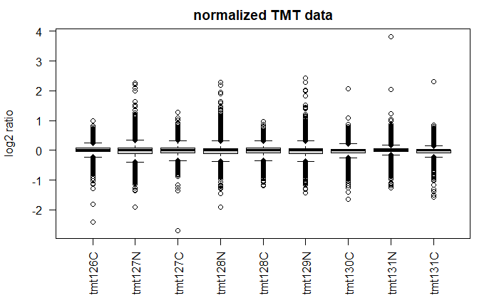

```r
##########################################################################################
quantInput = psmQuantFiltered[,c(1:12,15:17)]
saveRDS(quantInput, paste(baseRepository, '/dataset_peptideQuantDataPreDEqMS.rds', sep = ''))
quantInputLog = quantInput[,c(6,5,7:15)]
quantInputLog[,3:11][quantInputLog[,3:11] == 0] = NA
quantInputLog[,3:11] = log2(quantInputLog[,3:11])
quantInputNormalized = medianSweeping(quantInputLog, group_col = 2)
boxplot(quantInputNormalized, las = 2, ylab = 'log2 ratio', main = 'normalized TMT data')
```

All of the data look tight. Good. Lets continue with the DEqMS analysis. We need to build our sample table.

```r
##########################################################################################
cond = as.factor(c('dmso','bsd','dmso','bsd','dmso','bsd','resc','resc','resc'))
design = model.matrix(~0+cond)
colnames(design) = gsub('cond', '', colnames(design))
```

Now we can build the Limma model.

```r
##########################################################################################
geneMatrix = as.matrix(quantInputNormalized)
limmaFit1 = lmFit(geneMatrix, design)
limmaContrasts = c('bsd - dmso', 'bsd - resc', 'resc - dmso')
limmaContrastDesign =  makeContrasts(contrasts = limmaContrasts, levels = design)
limmaFit2 = eBayes(contrasts.fit(limmaFit1, contrasts = limmaContrastDesign))
```

```r
##########################################################################################
psmCountTable = as.data.frame(table(quantInput$gene))
rownames(psmCountTable) = psmCountTable$Var1
limmaFit2$count = psmCountTable[rownames(limmaFit2$coefficients),2]
limmaFit3 = spectraCounteBayes(limmaFit2)
head(limmaFit3$coefficients)
```

```
       Contrasts
         bsd - dmso  bsd - resc  resc - dmso
  A2M    0.10151951  0.50106197 -0.399542461
  AAAS   0.05848262  0.04977070  0.008711916
  AACS   0.19613493  0.43248886 -0.236353926
  AAGAB  0.23655401  0.23612647  0.000427541
  AAK1   0.02014436 -0.04180311  0.061947476
  AAMDC -0.15285039  0.01270304 -0.165553432
```

```r
##
deqmsResults = outputResult(limmaFit3, coef_col = 1)
dim(deqmsResults)
```

```
[1] 6260   11
```

```r
write.table(deqmsResults,
            paste(baseRepository, '/dataset_deqms_tc32_bsd-dmso.csv', sep = ''),
            sep = ',', row.names = FALSE, quote = FALSE)
##
deqmsResults = outputResult(limmaFit3, coef_col = 2)
dim(deqmsResults)
```

```
[1] 6260   11
```

```r
write.table(deqmsResults,
            paste(baseRepository, '/dataset_deqms_tc32_bsd-resc.csv', sep = ''),
            sep = ',', row.names = FALSE, quote = FALSE)
##
deqmsResults = outputResult(limmaFit3, coef_col = 3)
dim(deqmsResults)
```

```
[1] 6260   11
```

```r
write.table(deqmsResults,
            paste(baseRepository, '/dataset_deqms_tc32_resc-dmso.csv', sep = ''),
            sep = ',', row.names = FALSE, quote = FALSE)
```

Generate the variance plot to see the DEqMS model for the data.

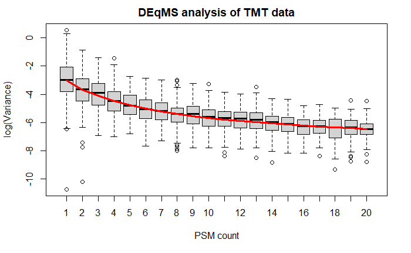

```r
##########################################################################################
VarianceBoxplot(limmaFit3, n=20, xlab = 'PSM count', main = 'DEqMS analysis of TMT data')
```

This looks as it should. Now let us make a volcano plot to show the data.

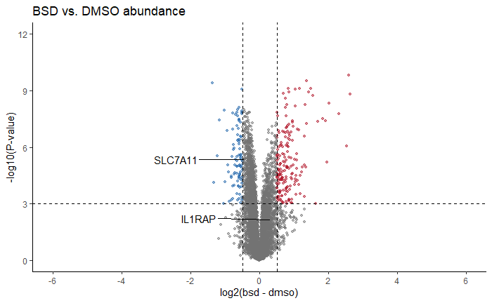

```r
##########################################################################################
deqmsResults = outputResult(limmaFit3, coef_col = 1)
deqmsResults$plotPValue = -log10(deqmsResults$sca.P.Value)
deqmsResults$pColors = ifelse(deqmsResults$logFC <= -0.5 & deqmsResults$plotPValue >= 3, brewer.pal(8,'RdBu')[8],
                              ifelse(deqmsResults$logFC >= 0.5 & deqmsResults$plotPValue >= 3, brewer.pal(8,'RdBu')[1],
                                     brewer.pal(8,'Greys')[6]))
goi = c('IL1RAP','SLC7A11')
deqmsResults$pText = ifelse(deqmsResults$gene %in% goi, deqmsResults$gene, '')
##
ggplot(deqmsResults, aes(logFC, plotPValue)) +
  geom_point(size = 1, color = deqmsResults$pColors, alpha = 0.5) +
  geom_text_repel(label = deqmsResults$pText, nudge_x = -2, max.overlaps = 10000) +
  labs(x = 'log2(bsd - dmso)', y = '-log10(P-value)', title = 'BSD vs. DMSO abundance') +
  scale_y_continuous(limits = c(0,12), breaks = seq(0,18,3)) +
  scale_x_continuous(limits = c(-6,6), breaks = seq(-6,6,2)) +
  geom_vline(xintercept = c(-0.5,0.5), linetype = 'dashed') +
  geom_hline(yintercept = 3, linetype = 'dashed') +
  theme_classic()
ggsave(paste(baseRepository, '/scatter_deqms_tc32_bsd-dmso.pdf', sep = ''),
       height = 2, width = 2, useDingbats = FALSE)
```

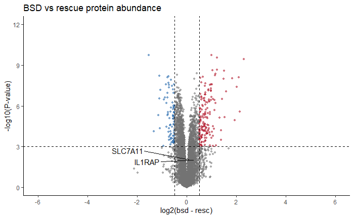

```r
##########################################################################################
deqmsResults = outputResult(limmaFit3, coef_col = 2)
deqmsResults$plotPValue = -log10(deqmsResults$sca.P.Value)
deqmsResults$pColors = ifelse(deqmsResults$logFC <= -0.5 & deqmsResults$plotPValue >= 3, brewer.pal(8,'RdBu')[8],
                              ifelse(deqmsResults$logFC >= 0.5 & deqmsResults$plotPValue >= 3, brewer.pal(8,'RdBu')[1],
                                     brewer.pal(8,'Greys')[6]))
goi = c('IL1RAP','SLC7A11')
deqmsResults$pText = ifelse(deqmsResults$gene %in% goi, deqmsResults$gene, '')
##
ggplot(deqmsResults, aes(logFC, plotPValue)) +
  geom_point(size = 1, color = deqmsResults$pColors, alpha = 0.5) +
  geom_text_repel(label = deqmsResults$pText, nudge_x = -2, max.overlaps = 10000) +
  labs(x = 'log2(bsd - resc)', y = '-log10(P-value)', title = 'BSD vs rescue protein abundance') +
  scale_y_continuous(limits = c(0,12), breaks = seq(0,18,3)) +
  scale_x_continuous(limits = c(-6,6), breaks = seq(-6,6,2)) +
  geom_vline(xintercept = c(-0.5,0.5), linetype = 'dashed') +
  geom_hline(yintercept = 3, linetype = 'dashed') +
  theme_classic()
ggsave(paste(baseRepository, '/scatter_deqms_tc32_bsd-resc.pdf', sep = ''),
       height = 2, width = 2, useDingbats = FALSE)
```

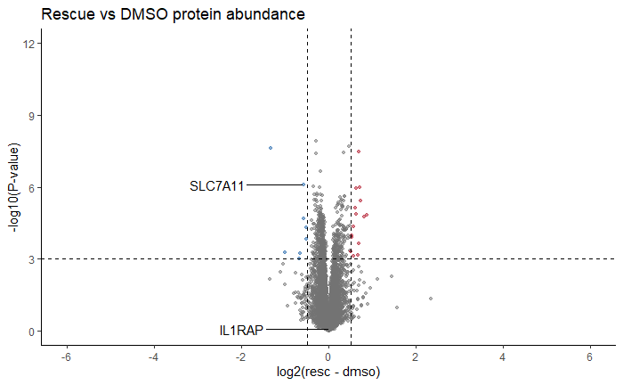

```r
##########################################################################################
deqmsResults = outputResult(limmaFit3, coef_col = 3)
deqmsResults$plotPValue = -log10(deqmsResults$sca.P.Value)
deqmsResults$pColors = ifelse(deqmsResults$logFC <= -0.5 & deqmsResults$plotPValue >= 3, brewer.pal(8,'RdBu')[8],
                              ifelse(deqmsResults$logFC >= 0.5 & deqmsResults$plotPValue >= 3, brewer.pal(8,'RdBu')[1],
                                     brewer.pal(8,'Greys')[6]))
goi = c('IL1RAP','SLC7A11')
deqmsResults$pText = ifelse(deqmsResults$gene %in% goi, deqmsResults$gene, '')
##
ggplot(deqmsResults, aes(logFC, plotPValue)) +
  geom_point(size = 1, color = deqmsResults$pColors, alpha = 0.5) +
  geom_text_repel(label = deqmsResults$pText, nudge_x = -2, max.overlaps = 10000) +
  labs(x = 'log2(resc - dmso)', y = '-log10(P-value)', title = 'Rescue vs DMSO protein abundance') +
  scale_y_continuous(limits = c(0,12), breaks = seq(0,18,3)) +
  scale_x_continuous(limits = c(-6,6), breaks = seq(-6,6,2)) +
  geom_vline(xintercept = c(-0.5,0.5), linetype = 'dashed') +
  geom_hline(yintercept = 3, linetype = 'dashed') +
  theme_classic()
ggsave(paste(baseRepository, '/scatter_deqms_tc32_resc-dmso.pdf', sep = ''),
       height = 2, width = 2, useDingbats = FALSE)
```

[session information not shown]